# Demand Prediction - data wrangling

# Description

### Data scope:

New York City, 2016-2019, hourly electricity consumption (MWh), weather variables

### Data sources:

Weather: National Oceanic Atmospheric Association (NOAA) Electricity demand: U.S. Energy Information Administration

### Aim:

1. Clean and format data for building machine learning models (remove irrelevant columns, remove NAs, fill in blanks, manage outliers)
2. Analyse covariance of variables

### Result notes:

Although the pearson correlation showed covariance between temperature variables in particular, it was decided not to remove them because of the potential for underlying predictive power of each temperature measurement depending upon season.

## 1. Weather

View columns and remove irrelevant variables e.g. related to daily, monthly rather than hourly. Backup columns etc.

```r
#print(colnames(weather))
weather_filtered <- weather %>%
  select(-starts_with("Daily"), -starts_with("Monthly"), -starts_with("ShortDuration"),-starts_with("Backup")) %>%
  select(-c(1,3:13,17,21,22,26,29:36))
print(colnames(weather_filtered))
```

```
##  [1] "DATE"                      "HourlyDewPointTemperature"
##  [3] "HourlyDryBulbTemperature"  "HourlyPrecipitation"
##  [5] "HourlyPressureChange"      "HourlyPressureTendency"
##  [7] "HourlyRelativeHumidity"    "HourlyStationPressure"
##  [9] "HourlyVisibility"          "HourlyWetBulbTemperature"
## [11] "HourlyWindGustSpeed"       "HourlyWindSpeed"
```

Create date and hour columns, remove duplicated dates/hours, convert columns to numeric

```r
# create date and hour columns
weather_filtered <- weather_filtered %>%
  separate(DATE, into = c("date", "hour"), sep = "T")
weather_filtered$hour <- substr(weather_filtered$hour, 1, 2)
# remove duplicates for the date and hour columns
weather_filtered <- weather_filtered[!duplicated(weather_filtered[, c("date", "hour")], fromFirst = TRUE), ]
# convert columns to numeric
weather_filtered[, 3:10] <- lapply(weather_filtered[, 3:10], as.numeric)
```

### 1.1 Weather NAs

Remove columns with too many NAs Fill remaining NAs with linear interpolation

```r
nas <- colSums(is.na(weather_filtered))
print(nas/nrow(weather_filtered)*100)
```

```
##                      date                      hour HourlyDewPointTemperature
##                 0.0000000                 0.0000000                 0.1346070
##  HourlyDryBulbTemperature       HourlyPrecipitation      HourlyPressureChange
##                 0.1143436                14.7894051                71.9047619
##    HourlyPressureTendency    HourlyRelativeHumidity     HourlyStationPressure
##                71.9047619                 0.1215805                 1.1043566
##          HourlyVisibility  HourlyWetBulbTemperature       HourlyWindGustSpeed
##                 1.3301491                 1.1448835                84.9804603
##           HourlyWindSpeed
##                12.7645101
```

```r
# remove HourlyPressureChange, HourlyPressureTendency, HourlyWindGustSpeed because of high percentage of NAs
weather_filtered <- weather_filtered %>%
  select(-HourlyPressureChange,-HourlyPressureTendency,-HourlyWindGustSpeed)
# fill remaining NAs using linear interpolation
na_columns <- colnames(weather_filtered)[colSums(is.na(weather_filtered)) > 0]
weather_filtered[na_columns] <- na.approx(weather_filtered[na_columns])
#check_nas <- colSums(is.na(weather_filtered))
#print(check_nas)
# still 4 rows of NAs, remove because low number and entire rows are NA
weather_filtered <- na.omit(weather_filtered)

check_nas <- colSums(is.na(weather_filtered))
print(check_nas)
```

```
##                      date                      hour HourlyDewPointTemperature
##                         0                         0                         0
##  HourlyDryBulbTemperature       HourlyPrecipitation    HourlyRelativeHumidity
##                         0                         0                         0
##     HourlyStationPressure          HourlyVisibility  HourlyWetBulbTemperature
##                         0                         0                         0
##           HourlyWindSpeed
##                         0
```

## 2. Demand

Create date and hour columns in same format as weather_dh

```r
# create date and hour columns
split_datetime <- strsplit(demand$Category, " ")
demand$date <- sapply(split_datetime, "[[", 1)
demand$hour <- sapply(split_datetime, "[[", 2)
demand$hour <- gsub("H", "", demand$hour)
demand <- demand %>% select(-Category)

#convert data and hour column to same format as weather_dh
demand_date <- demand %>%
  mutate(date = format(as.Date(date, format = "%m/%d/%Y"), format = "%Y-%m-%d"))
```

### 2.1 NAs

No NAs found

```r
#check for NAs
print(colSums(is.na(demand)))
```

```
##  MWh date hour
##    0    0    0
```

### 2.2 Outliers

Detect outliers using IQR. Remove extreme lower outliers

```r
# identify outliers
Q1 <- quantile(demand_date$MWh, 0.25)
Q3 <- quantile(demand_date$MWh, 0.75)
IQR <- Q3 - Q1
threshold <- 1.5
outliers <- demand_date[demand_date$MWh < (Q1 - threshold * IQR), ]
# remove low outliers
demand_out <- demand_date[demand_date$MWh >= (Q1 - threshold * IQR), ]
```

## 3. Merge datasets

```r
master <- merge(weather_filtered, demand_out, by.x = c("date", "hour"), by.y = c("date", "hour"), all = FALSE)
```

Check most days have 24hrs Filter for only 2016, 2017, 2018 and 2019 to avoid COVID affected years Add weekend/weekday and seasons variables

```r
#find out how many days per year
year_count <- master %>%
  mutate(year = year(date),
         day_of_year = yday(date))
count_unique_days_per_year <- year_count %>%
  group_by(year) %>%
  summarize(unique_days_count = n_distinct(day_of_year))
print(count_unique_days_per_year)
```

```
## # A tibble: 8 × 2
##    year unique_days_count
##   <dbl>             <int>
## 1  2015               184
## 2  2016               366
## 3  2017               365
## 4  2018               365
## 5  2019               365
## 6  2020               366
## 7  2021               365
## 8  2022               324
```

```r
master <- master %>%
  filter(year(date) %in% c(2016, 2017, 2018, 2019))

#check most days have 24hrs
number_24hrs <- table(table(master$date))
#yes majority do

# add days of the week
master$date <- as.Date(master$date)
master$dayofweek <- weekdays(master$date)
master$weekdayorweekend <- ifelse(master$dayofweek %in% c("Saturday", "Sunday"), "Weekend", "Weekday")
master <- master %>% select(-dayofweek)

#add season
season_func <- function(date) {
  month <- as.integer(format(date, "%m"))

  if (month >= 3 && month <= 5) {
    return("Spring")
  } else if (month >= 6 && month <= 8) {
    return("Summer")
  } else if (month >= 9 && month <= 11) {
    return("Autumn")
  } else {
    return("Winter")
  }
}
master$season <- sapply(master$date, season_func)
#remove hourly reference from variable titles
colnames(master) <- sub("Hourly", "", colnames(master))
```

## 4. Plots

### 4.1 Pearson Correlation Coefficent Matrix

Plot a correlation matrix to analyse linear relationships between numeric variables

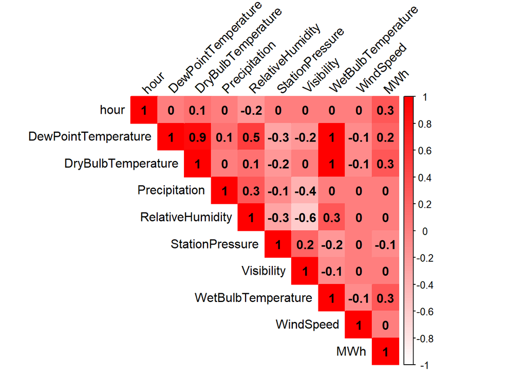

```r
## create a pearson correlation matrix and plot
master_cor <- master %>% select(-date,-weekdayorweekend,-season)
master_cor$hour <- as.numeric(master_cor$hour)
cor_matrix <- round(cor(master_cor), 1)
corrplot(
  cor_matrix,
  method = "color",
  col = colorRampPalette(c("white", "red"))(100),
  type = "upper",
  tl.col = "black",
  tl.srt = 45,
  addCoef.col = "black",
)
```

### 4.2 Variable Plots

View relationship between independent and dependent variables using scatter plots

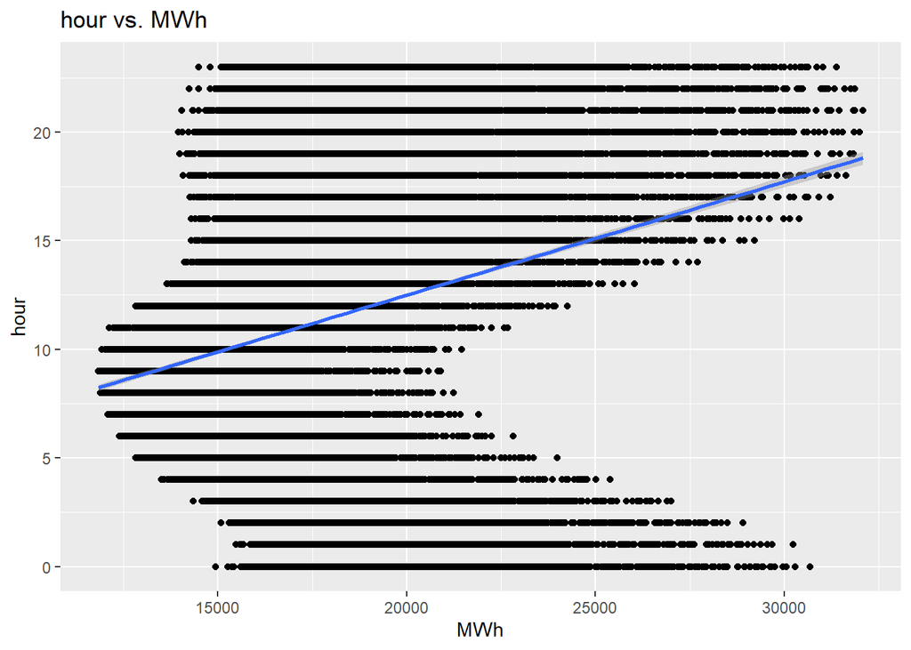

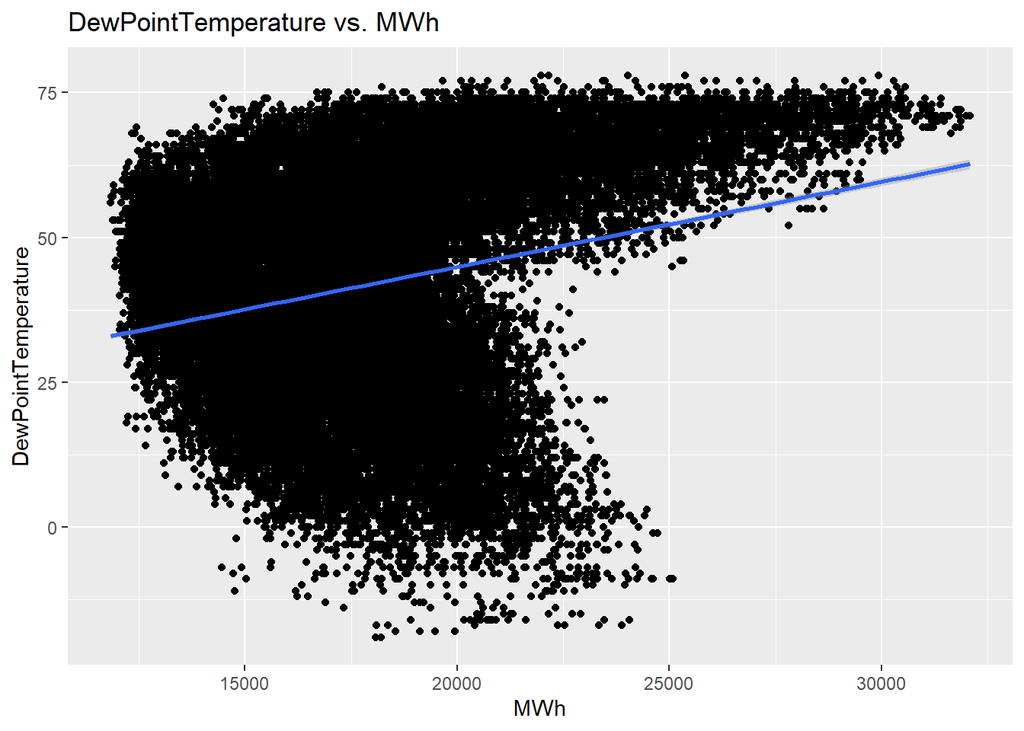

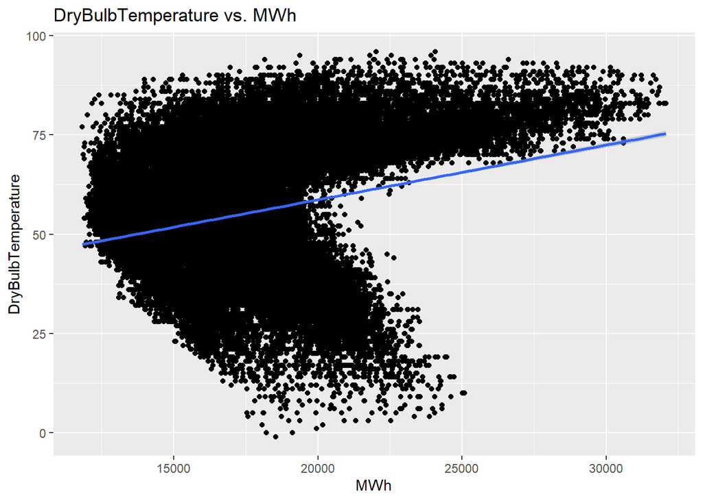

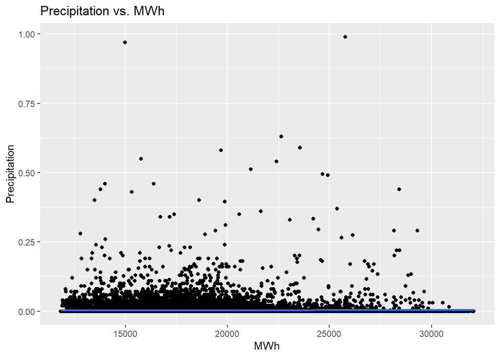

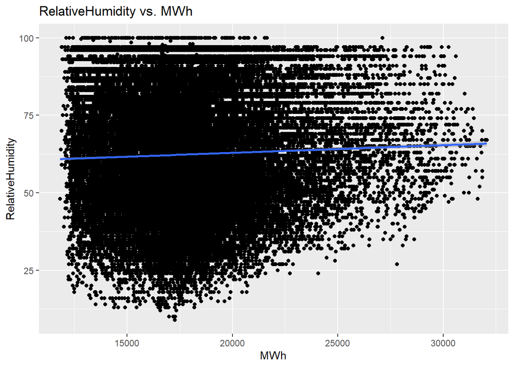

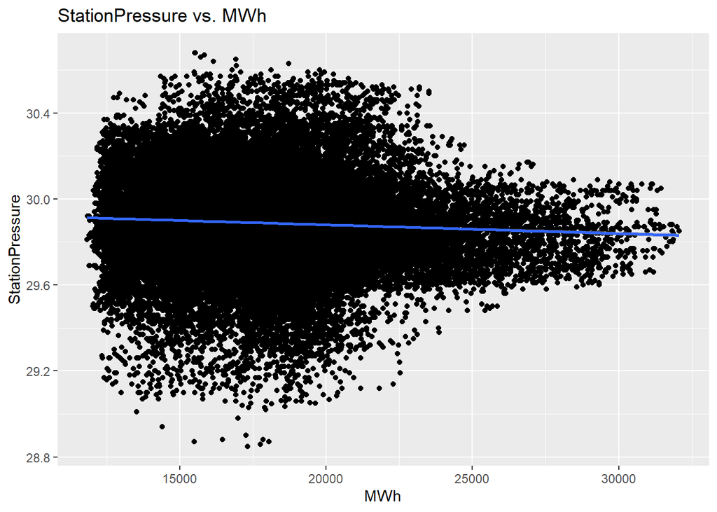

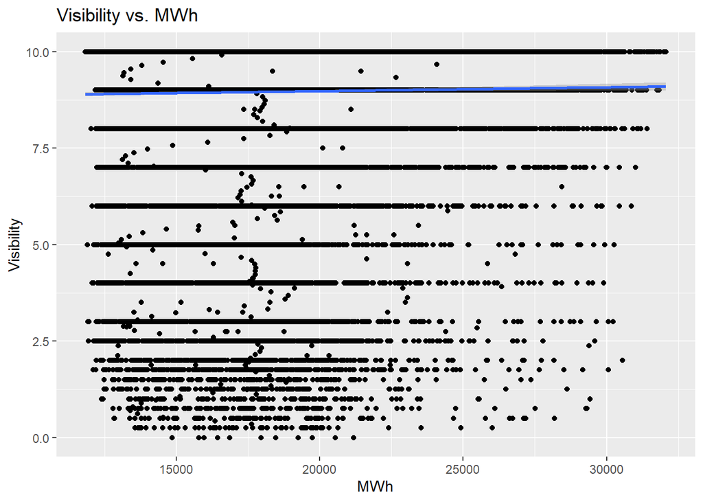

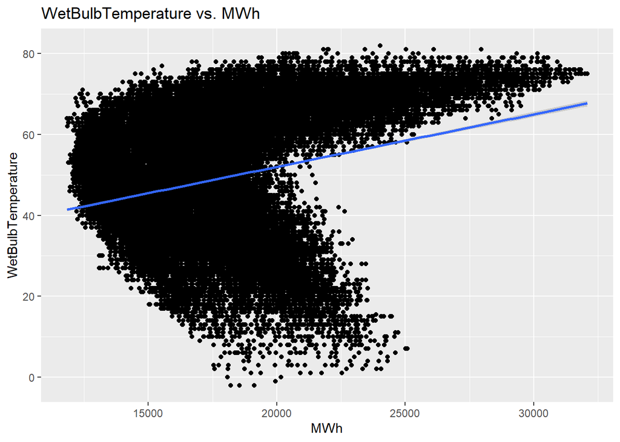

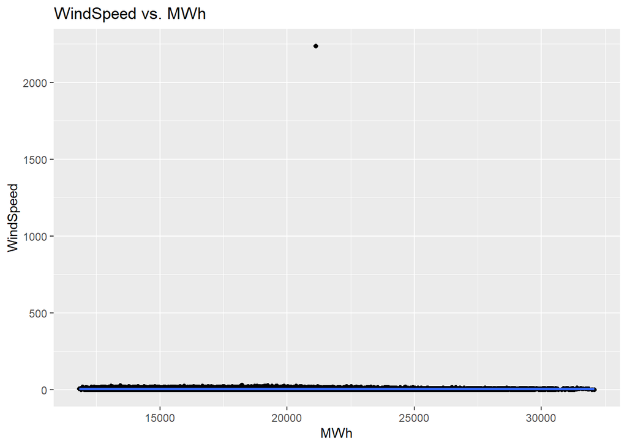

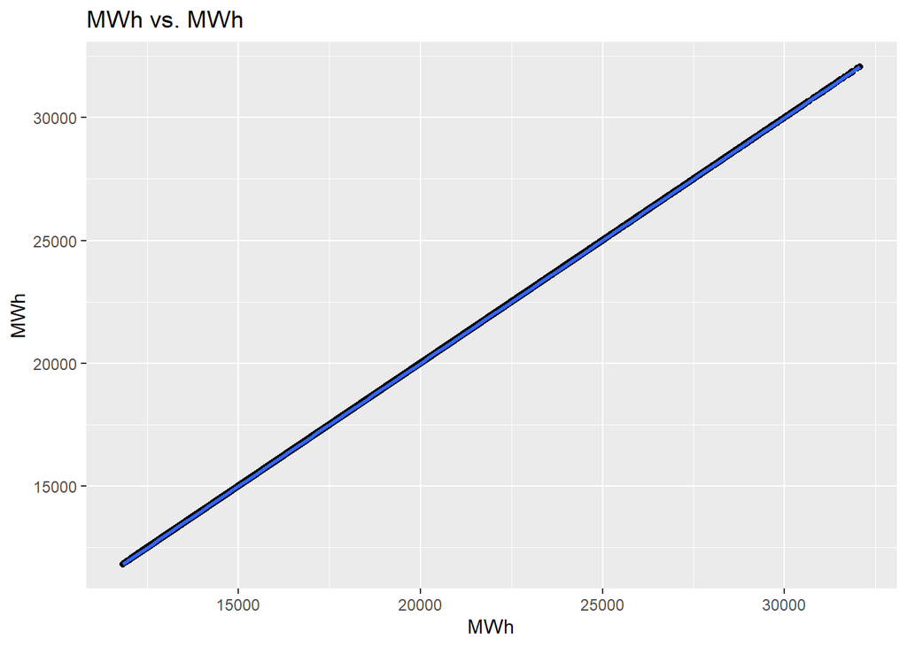

```r
plots_list <- list()

for (i in 1:10) {
  p <- ggplot(master_cor, aes(x = master_cor[, 10], y = master_cor[, i])) +
    geom_point() +
    geom_smooth(method = "lm") +
    labs(x = names(master_cor)[10], y = names(master_cor)[i]) +
    ggtitle(paste(names(master_cor)[i], "vs.", names(master_cor)[10]))

  plots_list[[i]] <- p
}

for (i in 1:length(plots_list)) {
  print(plots_list[[i]])
}
```

### 4.3 Perform ANOVA on categorical variables vs MWh

Result: the low p values suggest a statistically significant effect of these variables on the dependent variable.

```r
# perform ANOVA analysis for the categorical variables
anova_weekdayorweekend <- aov(MWh ~ weekdayorweekend, data = master)
anova_season <- aov(MWh ~ season, data = master)
print(summary(anova_weekdayorweekend))
```

```
##                     Df    Sum Sq   Mean Sq F value Pr(>F)
## weekdayorweekend     1 1.348e+10 1.348e+10    1241 <2e-16 ***
## Residuals        35012 3.805e+11 1.087e+07
## ---
## Signif. codes:  0 '***' 0.001 '**' 0.01 '*' 0.05 '.' 0.1 ' ' 1
```

```r
print(summary(anova_season))
```

```
##                Df    Sum Sq   Mean Sq F value Pr(>F)
## season          3 8.923e+10 2.974e+10    3417 <2e-16 ***
## Residuals   35010 3.047e+11 8.705e+06
## ---
## Signif. codes:  0 '***' 0.001 '**' 0.01 '*' 0.05 '.' 0.1 ' ' 1
```